# RNAseq in Bioconductor exercises (part 4)

Rockefeller University, Bioinformatics Resource Centre

https://rockefelleruniversity.github.io/RU_RNAseq/

In todays session we will work with some of the RNAseq data of adult mouse tissues from Bing Ren’s lab, Liver and Heart.

- More information on liver data [can be found here](https://www.encodeproject.org/experiments/ENCSR000CHB/)
- More information on heart data [can be found here](https://www.encodeproject.org/experiments/ENCSR000CGZ/)
- Differential expression results for Heart minus Liver can be found in the data directory:
- DGE - **data/Heart_minus_liver.csv**
- Counts - **data/gC_TissueFull.RData**

## Exercises

### 1. Over Representaion Analysis - GO terms

Identify GO term cellular component groups enriched in genes significantly upregulated in Liver with clusterProfiler using Fishers exact test. What are the top 5 terms? Make a dotplot of these terms. Also try an enrichment map plot for the top 20 groups.

*HINT: “CC” is the ontology category for cellular component GO terms*

|  | ID | Description | GeneRatio | BgRatio | RichFactor | FoldEnrichment | zScore | pvalue | p.adjust | qvalue | geneID | Count |
| --- | --- | --- | --- | --- | --- | --- | --- | --- | --- | --- | --- | --- |
| GO:0005777 | GO:0005777 | peroxisome | 71/2639 | 151/28618 | 0.4701986754966888 | 5.098956307451398 | 16.09575837357941 | 1.117119940906059e-33 | 3.652982206762812e-31 | 3.045621733628097e-31 | 15926/111175/74205/11611/67247/16922/74159/18633/12359/26458…… | 71 |
| GO:0042579 | GO:0042579 | microbody | 71/2639 | 151/28618 | 0.4701986754966888 | 5.098956307451398 | 16.09575837357941 | 1.117119940906059e-33 | 3.652982206762812e-31 | 3.045621733628097e-31 | 15926/111175/74205/11611/67247/16922/74159/18633/12359/26458…… | 71 |
| GO:0032994 | GO:0032994 | protein-lipid complex | 32/2639 | 46/28618 | 0.6956521739130435 | 7.543832479364712 | 14.15667624073424 | 4.134453464804307e-23 | 9.013108553273388e-21 | 7.514550507960108e-21 | 13167/11807/18979/66881/11813/11425/11812/11816/54135/20210/20211/20208/20209/109815/20288/16816/15439/16835/11806/11814/11808/66113/15450/56535/103161/11818/238055/14756/12759/223672/71898/55938 | 32 |
| GO:0034358 | GO:0034358 | plasma lipoprotein particle | 30/2639 | 43/28618 | 0.6976744186046512 | 7.565762224944263 | 13.73241093978692 | 8.320485556582687e-22 | 1.088319510801016e-19 | 9.073708459599645e-20 | 11807/18979/66881/11813/11425/11812/11816/54135/20210/20211/20208/20209/109815/20288/16816/15439/16835/11806/11814/11808/66113/15450/103161/11818/238055/14756/12759/223672/71898/55938 | 30 |
| GO:1990777 | GO:1990777 | lipoprotein particle | 30/2639 | 43/28618 | 0.6976744186046512 | 7.565762224944263 | 13.73241093978692 | 8.320485556582687e-22 | 1.088319510801016e-19 | 9.073708459599645e-20 | 11807/18979/66881/11813/11425/11812/11816/54135/20210/20211/20208/20209/109815/20288/16816/15439/16835/11806/11814/11808/66113/15450/103161/11818/238055/14756/12759/223672/71898/55938 | 30 |

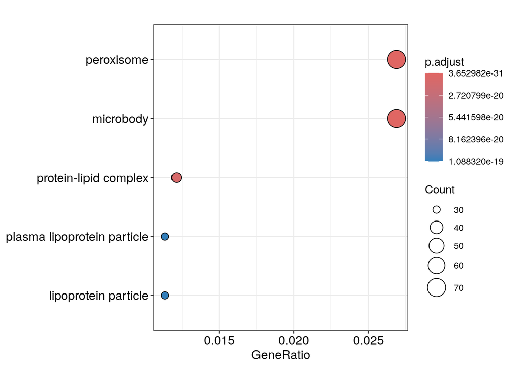

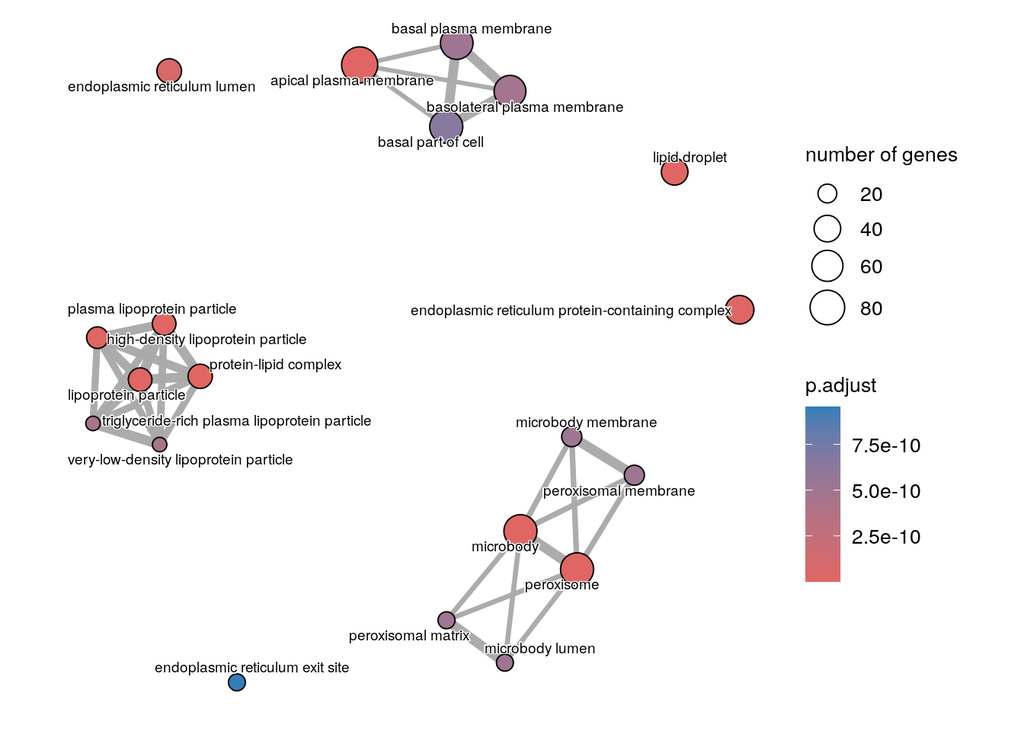

### 2. Over Representaion Analysis - MSigDB

Take the same genes (significantly upregulated in Liver) and check enrichment in gene sets from MSigDB Hallmarks. Check the results with a dotplot. Rerun this but subset the universe appropriately. Compare the dotplots.

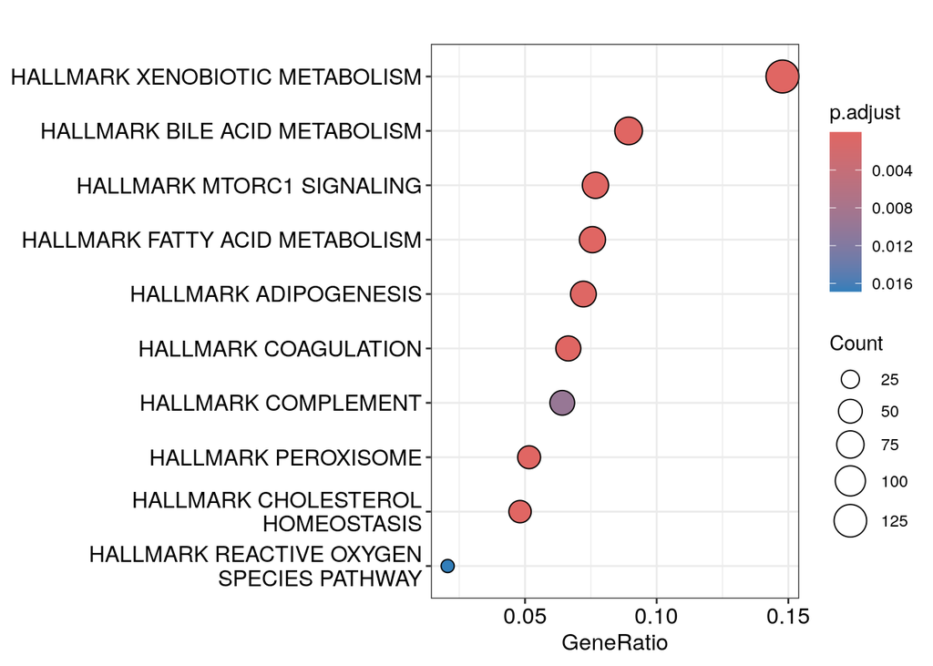

```r
mm_h <- msigdbr(species = "Mus musculus", category = "H")[,c("gs_name","entrez_gene")]

sig_gene_enr1 <- enricher(UpInLiver_ID, TERM2GENE = mm_h)
dotplot(sig_gene_enr1)
```

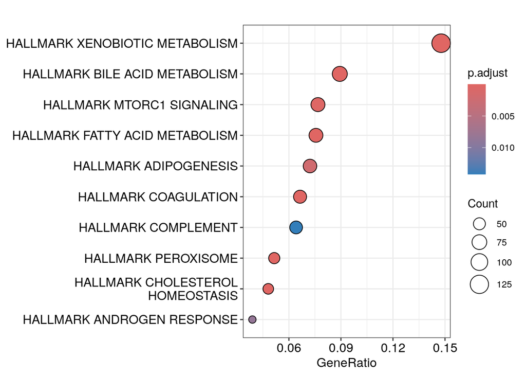

```r
sig_gene_enr2 <- enricher(UpInLiver_ID, TERM2GENE = mm_h, universe = as.character(newResDF$ID))
dotplot(sig_gene_enr2)
```

```r
# the main groups are largely unchanged, but you can see a swap at the last group. This is because 15 genes from the Androgen gene set are not in the universe, so the background has shifted.
```

### 3. GSEA for KEGG enrichment

Run GSEA on our Heart vs Liver dataset, but specifically use the KEGG genesets. Show a dotplot of the clusterProfiler results. Show the top 20 terms. Show an emap of these terms. Lastly draw the classic GSEA plots for the top 3 terms.

*HINT: The “gseKEGG” is the clusterPorfiler function for looking at KEGG terms with GSEA*

```
## using 'fgsea' for GSEA analysis, please cite Korotkevich et al (2019).
```

```
## preparing geneSet collections...
```

```
## GSEA analysis...
```

```
## leading edge analysis...
```

```
## done...
```

```
##                ID                                               Description
## mmu04820 mmu04820 Cytoskeleton in muscle cells - Mus musculus (house mouse)
## mmu05415 mmu05415      Diabetic cardiomyopathy - Mus musculus (house mouse)
## mmu00830 mmu00830           Retinol metabolism - Mus musculus (house mouse)
## mmu00140 mmu00140 Steroid hormone biosynthesis - Mus musculus (house mouse)
## mmu04260 mmu04260   Cardiac muscle contraction - Mus musculus (house mouse)
## mmu00190 mmu00190    Oxidative phosphorylation - Mus musculus (house mouse)
##          setSize enrichmentScore       NES       pvalue     p.adjust
## mmu04820     222       0.7258365  2.935144 1.000000e-19 6.940000e-18
## mmu05415     180       0.7332201  2.900254 1.000000e-19 6.940000e-18
## mmu00830      86      -0.7856821 -2.754527 1.000000e-19 6.940000e-18
## mmu00140      77      -0.7984908 -2.748114 1.000000e-19 6.940000e-18
## mmu04260      78       0.7853715  2.743127 1.000000e-19 6.940000e-18
## mmu00190     111       0.7303096  2.710804 1.464658e-19 8.470607e-18
##                qvalue rank                   leading_edge
## mmu04820 4.042105e-18 2512 tags=64%, list=16%, signal=54%
## mmu05415 4.042105e-18 2319 tags=63%, list=15%, signal=54%
## mmu00830 4.042105e-18 2721 tags=81%, list=17%, signal=68%
## mmu00140 4.042105e-18 1798 tags=71%, list=11%, signal=64%
## mmu04260 4.042105e-18 1875 tags=58%, list=12%, signal=51%
## mmu00190 4.933586e-18 2500 tags=69%, list=16%, signal=59%
##                                                                                                                                                                                                                                                                                                          …
## mmu04820 22138/22003/17888/11464/17929/380698/13346/140781/14200/2192…
## mmu05415                                                                                                                                                                                 11739/18821/12865/20191/11938/12491/12895/20528/27273/21954/…
## mmu00830                                                                                                                                                                                                                                                                                                 …
## mmu00140                                                                                                                                                                                                                                                                                                 …
## mmu04260                                                                                                                                                                                                                                                                                                 …
## mmu00190                                                                                                                                                                                                                                                                                                 …
```

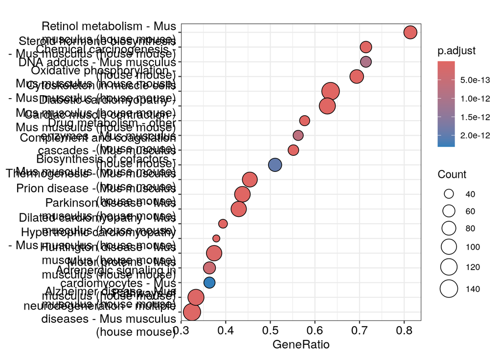

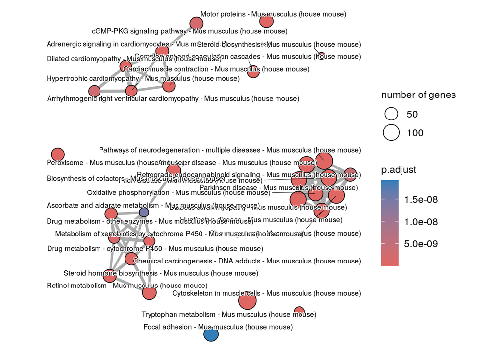

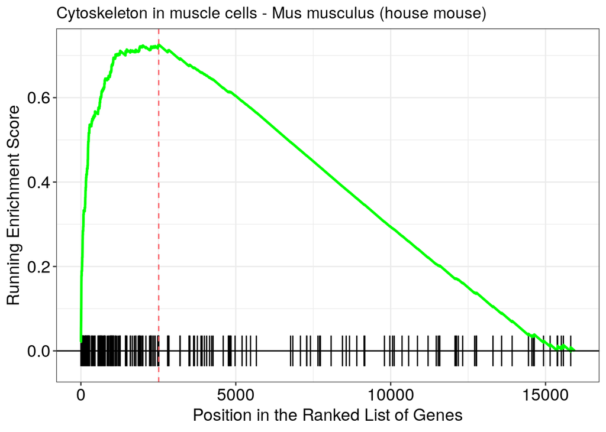

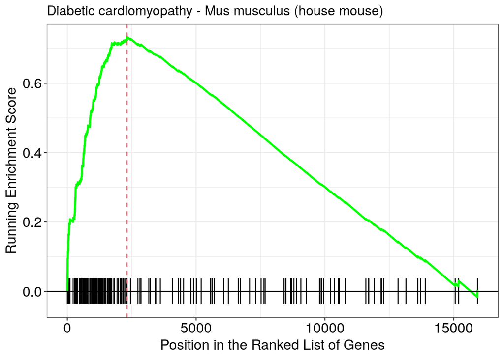

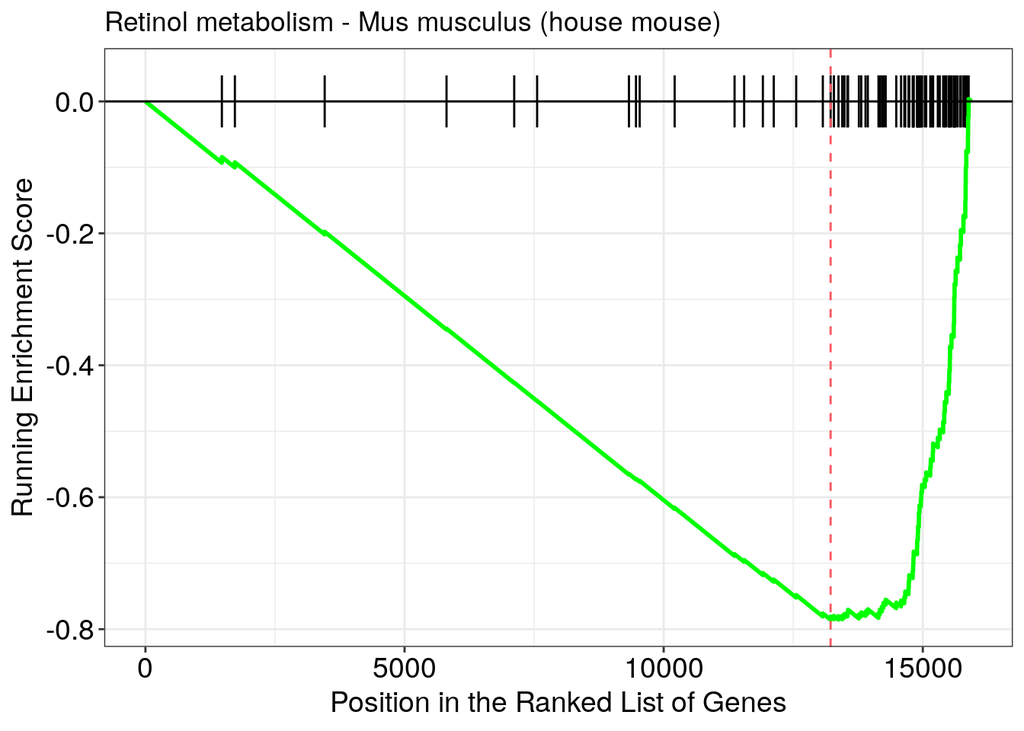

### 3. Additional GSEA plots for KEGG enrichment

Draw a heatmap of the genes driving enrichment in the top 3 KEGG terms. Use rlog counts, scale across row using a Z-score and include the kidney data as a reference point.

*HINT - The gene IDs are in the core_enrichment column of the clusterProfiler result*

```
## renaming the first element in assays to 'counts'
```

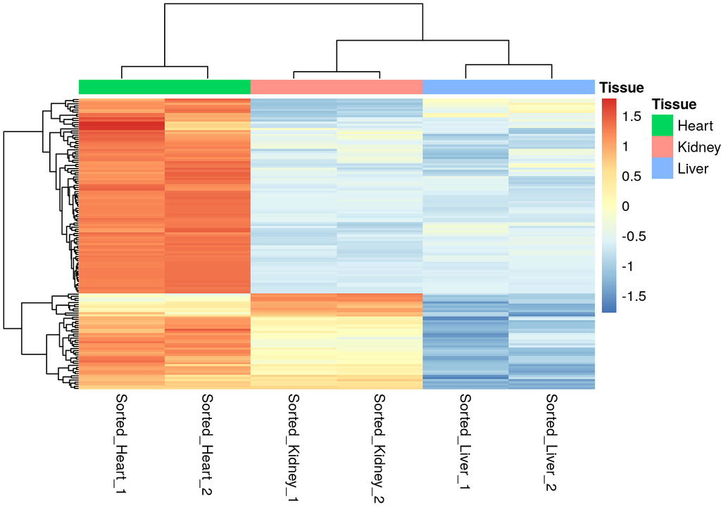